```r
knitr::opts_chunk$set(echo = TRUE)
```

# Visualisation of Worldwide COVID trends

By: Soumee Bhattacharya

# Overview

In this project I have tried to visualise the different global trends of COVID-19 and also seen the impact of factors like Global Peace Index (GPI) and Per capita gross domestic product (GDP) on the worldwide COVID cases and fatality.For this project I had consulted with Professor Blanca Himes who told to suggested me the topic and choose the parameter of my choice to see the trends. She also suggested that I plot the worldwide number of cases over a period of time for seeing how the virus has been spreading. I hope to be able to work on other parameters in future and see their impact on the worldwide COVID cases and total fatality

# Introduction

In December 2019, COVID-19 coronavirus was first identified in the Wuhan region of China. By March 11, 2020, the World Health Organization (WHO) categorized the COVID-19 outbreak as a pandemic. In this project I try to visulaise some of the data of cases worldwide and see the impact of factors like GDP per capita and and GPI index on the number of cases as well fatality rate on different countries of the world. GDP: Per capita gross domestic product (GDP) is a metric that breaks down a country's economic output per person and is calculated by dividing the GDP of a country by its population. Per capita GDP is a global measure for gauging the prosperity of nations and is used by economists, along with GDP, to analyze the prosperity of a country based on its economic growth. Small, rich countries and more developed industrial countries tend to have the highest per capita GDP. Global Peace Index (GPI) is a report produced by the Institute for Economics & Peace (IEP) which measures the relative position of nations' and regions' peacefulness. The GPI ranks 172 independent states and territories (99.7 per cent of the world's population) according to their levels of peacefulness.

# Methods

I have utilised the worldwide COVID data series from WHO, a GDP and GPI data series, along with a COVID time series dataset by the John Hopkins University. I have GGPLOT to visualise different trends across the world. I have joined different dataframes to be able to visualise the trends. I have also found out the fatality rate in each country by dividing total number of deaths in the all countries divided by total number of reported cases.

```r
# Load the readr, ggplot2, and dplyr packages
library(ggplot2)
library(lubridate)
library(patchwork)
library(readr)
library(maps)
library(viridis)
library(dplyr)
#Loading the dataframes,the worldwide covid data, GDP per capita of countries and worldmap
covid_data<-read.csv("WHO-COVID-19-global-data.csv",header = TRUE, stringsAsFactors = FALSE)
GDP_data<-read.csv("GDP.csv",header = TRUE, stringsAsFactors = FALSE)
map1<- read.csv("countrycodes.csv",header = TRUE, stringsAsFactors = FALSE)
world <- map_data("world")
```

```r
#Visualising Worldwine New Covid Cases

covid_data<-covid_data%>%
  rename(Date_reported=X...Date_reported)
covid_data$Date_reported <- as.Date(covid_data$Date_reported, "%Y-%m-%d")
```

# Results

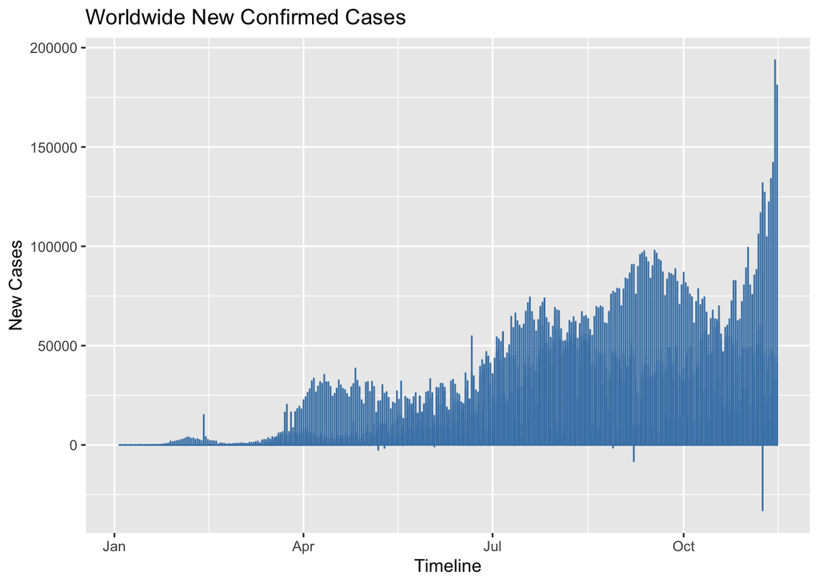

```r
#Plotting the number of new cases per day from 3rd Jan 2020 to 15th November 2020
ggplot (data = covid_data, aes(x = Date_reported , y = New_cases)) +
    geom_line(colour='steelblue')+
  labs(title="Worldwide New Confirmed Cases",x = "Timeline", y = "New Cases")
```

```r
datacov <- read.csv("/Users/apple/Desktop/time_series_covid19_confirmed_global.csv")
```

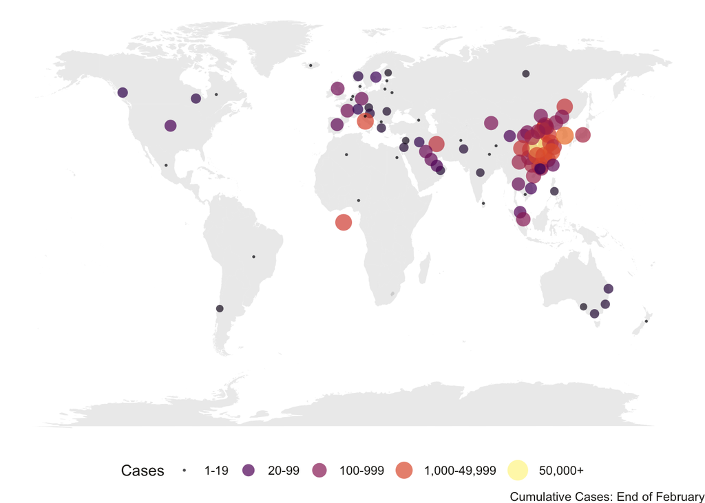

```r
# cutoffs based on the number of cases
mybreaks <- c(1, 20, 100, 1000, 50000)

#Plotting Cases Worldwide cases by end of February
ggplot() +
 geom_polygon(data = world, aes(x=long, y = lat, group = group), fill="grey", alpha=0.3) +
 geom_point(data=datacov, aes(x=Long, y=Lat, size=`X2.28.20`, color=`X2.28.20`),stroke=F, alpha=0.7) +
 scale_size_continuous(name="Cases", trans="log", range=c(1,7),breaks=mybreaks, labels = c("1-19", "20-99", "100-999", "1,000-49,999", "50,000+")) +
    # scale_alpha_continuous(name="Cases", trans="log", range=c(0.1, 0.9),breaks=mybreaks) +
    scale_color_viridis_c(option="inferno",name="Cases", trans="log",breaks=mybreaks, labels = c("1-19", "20-99", "100-999", "1,000-49,999", "50,000+")) +
    theme_void() +
    guides( colour = guide_legend()) +
    labs(caption = "Cumulative Cases: End of February") +
    theme(
      legend.position = "bottom",
      text = element_text(color = "#22211d"),
      plot.background = element_rect(fill = "#ffffff", color = NA),
      panel.background = element_rect(fill = "#ffffff", color = NA),
      legend.background = element_rect(fill = "#ffffff", color = NA)
    )
```

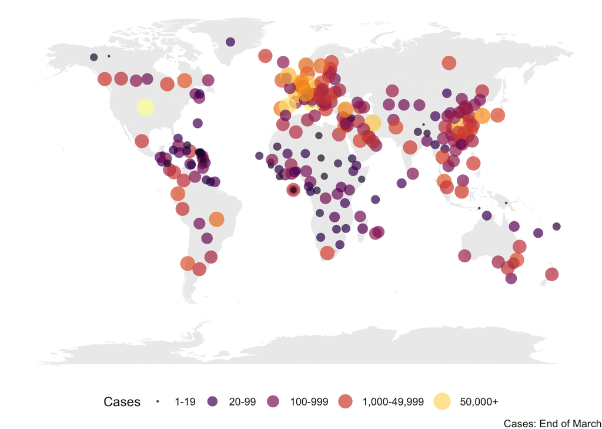

```r
#Plotting Cases Worldwide cases by end of March
ggplot() +
 geom_polygon(data = world, aes(x=long, y = lat, group = group), fill="grey", alpha=0.3) +
 geom_point(data=datacov, aes(x=Long, y=Lat, size=`X3.28.20`, color=`X3.28.20`),stroke=F, alpha=0.7) +
 scale_size_continuous(name="Cases", trans="log", range=c(1,7),breaks=mybreaks, labels = c("1-19", "20-99", "100-999", "1,000-49,999", "50,000+")) +
    # scale_alpha_continuous(name="Cases", trans="log", range=c(0.1, 0.9),breaks=mybreaks) +
    scale_color_viridis_c(option="inferno",name="Cases", trans="log",breaks=mybreaks, labels = c("1-19", "20-99", "100-999", "1,000-49,999", "50,000+")) +
    theme_void() +
    guides( colour = guide_legend()) +
    labs(caption = "Cases: End of March") +
    theme(
      legend.position = "bottom",
      text = element_text(color = "#22211d"),
      plot.background = element_rect(fill = "#ffffff", color = NA),
      panel.background = element_rect(fill = "#ffffff", color = NA),
      legend.background = element_rect(fill = "#ffffff", color = NA)
    )
```

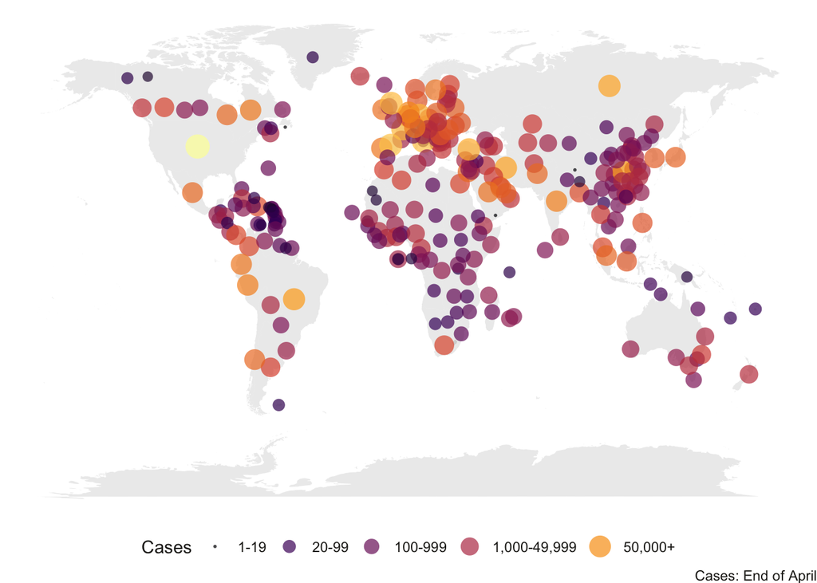

```r
#Plotting Cases Worldwide cases by end of April
ggplot() +
 geom_polygon(data = world, aes(x=long, y = lat, group = group), fill="grey", alpha=0.3) +
 geom_point(data=datacov, aes(x=Long, y=Lat, size=`X4.28.20`, color=`X4.28.20`),stroke=F, alpha=0.7) +
 scale_size_continuous(name="Cases", trans="log", range=c(1,7),breaks=mybreaks, labels = c("1-19", "20-99", "100-999", "1,000-49,999", "50,000+")) +
    # scale_alpha_continuous(name="Cases", trans="log", range=c(0.1, 0.9),breaks=mybreaks) +
    scale_color_viridis_c(option="inferno",name="Cases", trans="log",breaks=mybreaks, labels = c("1-19", "20-99", "100-999", "1,000-49,999", "50,000+")) +
    theme_void() +
    guides( colour = guide_legend()) +
    labs(caption = "Cases: End of April") +
    theme(
      legend.position = "bottom",
      text = element_text(color = "#22211d"),
      plot.background = element_rect(fill = "#ffffff", color = NA),
      panel.background = element_rect(fill = "#ffffff", color = NA),
      legend.background = element_rect(fill = "#ffffff", color = NA)
    )
```

```r
"Cumulative Cases: End of June"
```

```
## [1] "Cumulative Cases: End of June"
```

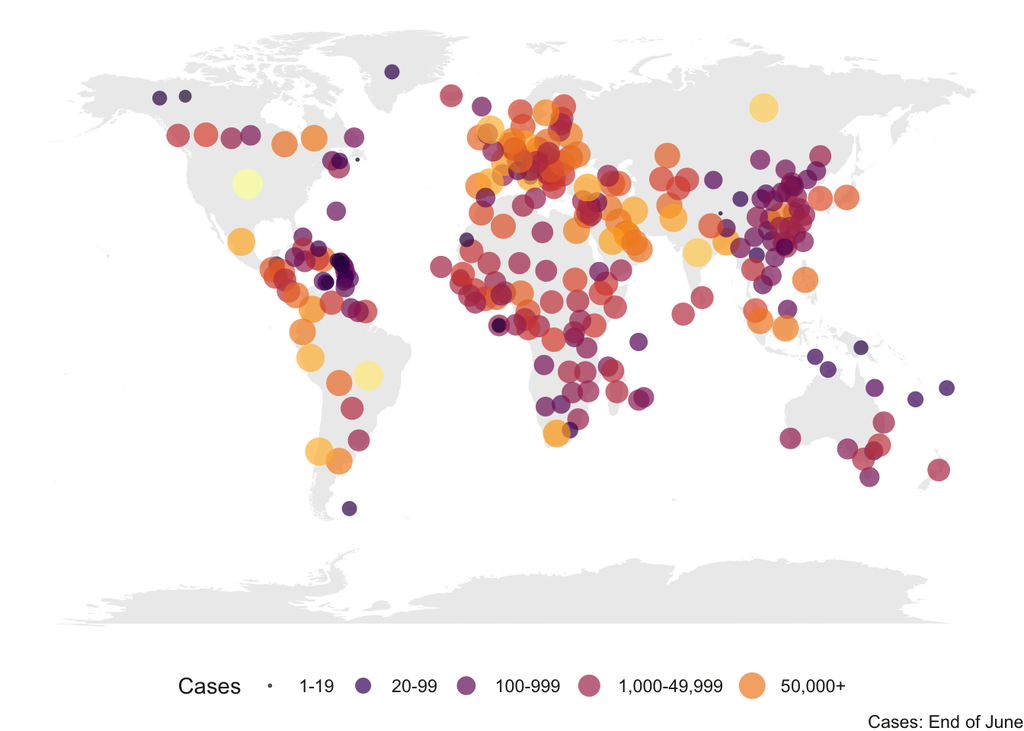

```r
ggplot() +
 geom_polygon(data = world, aes(x=long, y = lat, group = group), fill="grey", alpha=0.3) +
 geom_point(data=datacov, aes(x=Long, y=Lat, size=`X6.28.20`, color=`X6.28.20`),stroke=F, alpha=0.7) +
 scale_size_continuous(name="Cases", trans="log", range=c(1,7),breaks=mybreaks, labels = c("1-19", "20-99", "100-999", "1,000-49,999", "50,000+")) +
    # scale_alpha_continuous(name="Cases", trans="log", range=c(0.1, 0.9),breaks=mybreaks) +
    scale_color_viridis_c(option="inferno",name="Cases", trans="log",breaks=mybreaks, labels = c("1-19", "20-99", "100-999", "1,000-49,999", "50,000+")) +
    theme_void() +
    guides( colour = guide_legend()) +
    labs(caption = "Cases: End of June") +
    theme(
      legend.position = "bottom",
      text = element_text(color = "#22211d"),
      plot.background = element_rect(fill = "#ffffff", color = NA),
      panel.background = element_rect(fill = "#ffffff", color = NA),
      legend.background = element_rect(fill = "#ffffff", color = NA)
    )
```

# Timeline of the onset of pandemic

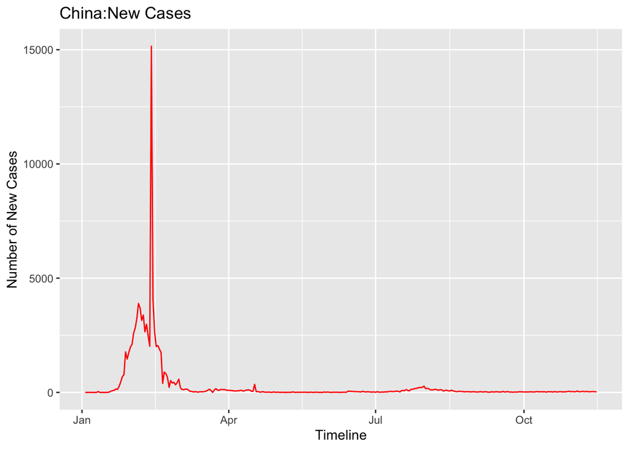

```r
China<-filter(covid_data, Country=="China")
ggplot (data = China, aes(x = Date_reported , y = New_cases)) +
    geom_line(colour='red')+
  labs(title="China:New Cases",x = "Timeline", y = "Number of New Cases")
```

In February, the majority of cases were in China. That changed in March when it really became a global outbreak: around March 14, the total number of cases outside China overtook the cases inside China. This was days after the WHO declared a pandemic.

```r
cov <- covid_data %>% dplyr::group_by(Country) %>% summarise(TotalCases  =  sum(New_cases),
                                                             TotalDeaths = sum(New_deaths),
                                                      Period = n())
#Fatality is defined as the number of deaths for the total number of cases in a particular country
cov$fatality <- cov$TotalDeaths/cov$TotalCases
```

```r
#Joining the COVID dataframe with worldwide GDP dataframe
#Merging the covid data with the world GDP data by the country
cov <- cov %>% inner_join(GDP_data, c("Country" = "country"))
```

# Impact of GDP on Fatality

GDP: Per capita gross domestic product (GDP) is a metric that breaks down a country's economic output per person and is calculated by dividing the GDP of a country by its population. Per capita GDP is a global measure for gauging the prosperity of nations and is used by economists, along with GDP, to analyze the prosperity of a country based on its economic growth. Small, rich countries and more developed industrial countries tend to have the highest per capita GDP.

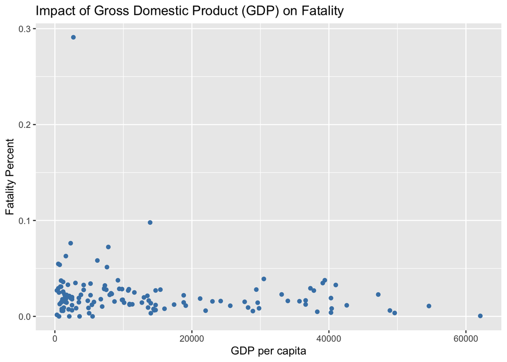

```r
#Visualisng the impact of GDP per capita on the Fatality rate due to COVID
ggplot (data = cov, aes(x = gdp_pc , y = fatality)) +
    geom_point(colour='steelblue')+
  labs(title="Impact of Gross Domestic Product (GDP) on Fatality",x  = "GDP per capita", y = "Fatality Percent")
```

```r
cov.new <- filter (cov, gdp_pc<10000 & fatality>0.02)
cov.new <-select(cov.new,Country,fatality,gdp_pc)
cov.new<-cov.new %>% arrange(desc(fatality))

cov.new
```

```
## # A tibble: 41 x 3
##    Country     fatality gdp_pc
##    <chr>          <dbl>  <int>
##  1 Yemen         0.291    2700
##  2 Sudan         0.0763   2300
##  3 Ecuador       0.0724   7800
##  4 Chad          0.0629   1600
##  5 Egypt         0.0583   6200
##  6 Liberia       0.0547    500
##  7 Niger         0.0538    700
##  8 China         0.0514   7600
##  9 Peru          0.0376   9200
## 10 Afghanistan   0.0373    900
## # ... with 31 more rows
```

The top 5 countries with the highest fatality rate due to COVID are Yemen, Sudan, Ecuacor, Chad. Egypt in the decreasing order of fatality rate. The new cases and COVID deaths in the top two countries (Yemen and Sudan) with high fatality rate are plotted

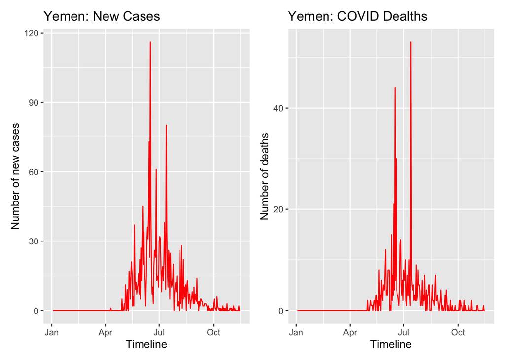

```r
yemen<-filter(covid_data, Country=="Yemen")
Y1<-ggplot (data = yemen, aes(x = Date_reported , y = New_cases)) +
    geom_line(colour='red')+
  labs(title="Yemen: New Cases",x = "Timeline", y = "Number of new cases")

Y2<-ggplot (data = yemen, aes(x = Date_reported , y = New_deaths)) +
    geom_line(colour='red')+
  labs(title="Yemen: COVID Dealths",x = "Timeline", y = "Number of deaths")

Y1+Y2
```

In Yemen the number of cases peaked during June-July-August with peak number of COVID deaths during this period of time in the region

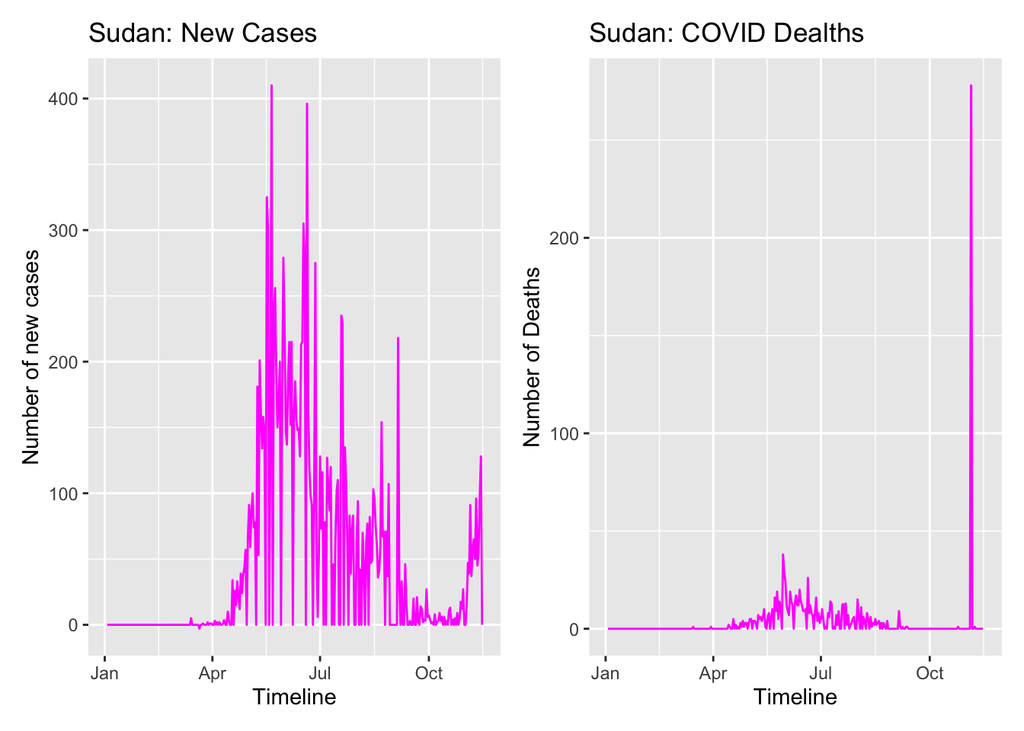

```r
sudan<-filter(covid_data, Country=="Sudan")
S1<-ggplot (data = sudan, aes(x = Date_reported , y = New_cases)) +
    geom_line(colour='magenta')+
  labs(title="Sudan: New Cases",x = "Timeline", y = "Number of new cases")

S2<-ggplot (data = sudan, aes(x = Date_reported , y = New_deaths)) +
    geom_line(colour='magenta')+
  labs(title="Sudan: COVID Dealths",x = "Timeline", y = "Number of Deaths")

S1+S2
```

In Sudan the number of cases peaked during May-July after which it steadily decreased in Octobor and is again on the rise in November. We see a small bump in the number of deaths in the period where number of new COVID cases was increasing increasing, with a steep rise in the number of deaths in November which is quite alarming.

# Impact of the Global Peace Index on Fatality

Global Peace Index (GPI) is a report produced by the Institute for Economics & Peace (IEP) which measures the relative position of nations' and regions' peacefulness. The GPI ranks 172 independent states and territories (99.7 per cent of the world's population) according to their levels of peacefulness. The GPI data indicates Iceland, Denmark, New Zealand to be the most peaceful countries, and Somalia, Afghanistan, Sudan to be the least peaceful.

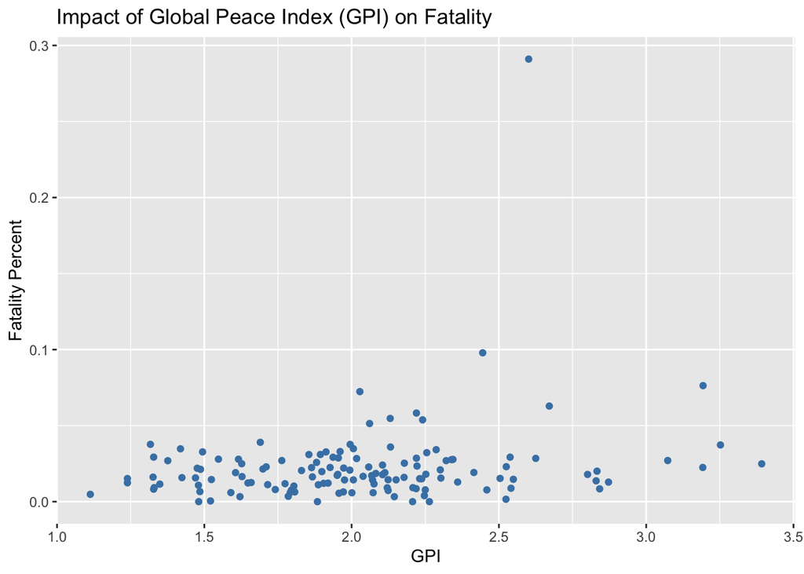

```r
#Visualisng the impact of GDP per capita on the Fatality rate due to COVID
ggplot (data = cov, aes(x = gpi_score , y = fatality)) +
    geom_point(colour='steelblue')+
  labs(title="Impact of Global Peace Index (GPI) on Fatality",x  = "GPI", y = "Fatality Percent")
```

In this we find that Fatality percent was lower in countries deemed most peaceful. We can find out some of the countries with highest fatality percent with a high GPI score

```r
cov.gpi <- filter (cov, gpi_score>2.3 & fatality>0.02)
cov.gpi <-select(cov.gpi, Country,fatality,gdp_pc,gpi_score)
cov.gpi<-cov.gpi %>% arrange(desc(fatality))

cov.gpi
```

```
## # A tibble: 16 x 4
##    Country                          fatality gdp_pc gpi_score
##    <chr>                               <dbl>  <int>     <dbl>
##  1 Yemen                              0.291    2700      2.60
##  2 Mexico                             0.0979  13900      2.44
##  3 Sudan                              0.0763   2300      3.19
##  4 Chad                               0.0629   1600      2.67
##  5 Afghanistan                        0.0373    900      3.25
##  6 Zimbabwe                           0.0293    500      2.54
##  7 Colombia                           0.0285   9800      2.62
##  8 Turkey                             0.0278   7500      2.34
##  9 Honduras                           0.0276   4200      2.34
## 10 Democratic Republic of the Congo   0.0270    300      3.07
## 11 South Africa                       0.0270  10700      2.32
## 12 Somalia                            0.0249    600      3.39
## 13 Myanmar                            0.0230   1400      2.52
## 14 Iraq                               0.0225   3800      3.19
## 15 Mauritania                         0.0209   2100      2.30
## 16 Pakistan                           0.0201   2500      2.83
```

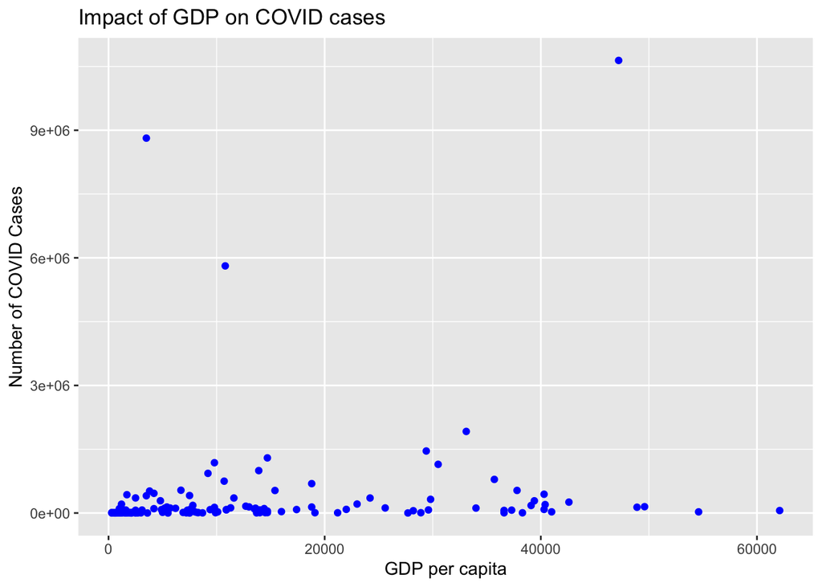

```r
#Visualising the impact of GDP on total number of COVID cases
ggplot (data = cov, aes(x = gdp_pc , y = TotalCases)) +
    geom_point(colour='blue')+
  labs(title="Impact of GDP on COVID cases ",x = "GDP per capita", y = "Number of COVID Cases")
```

Countries with GDP per capita less than 10000 were definitely has a spike in COVID cases. However we see a huge spike in total number of cases with a with GDP per capita greater than 40000. We try to find out these countries with the largest spikes in total number of COVID Cases

For Lower GDP per capita

```r
cov.gdp1 <- filter (cov, TotalCases>3000000 & gdp_pc<20000)
cov.gdp1 <-select(cov.gdp1, Country,TotalCases,gdp_pc,gpi_score)


cov.gdp1
```

```
## # A tibble: 2 x 4
##   Country TotalCases gdp_pc gpi_score
##   <chr>        <int>  <int>     <dbl>
## 1 Brazil     5810652  10800      2.02
## 2 India      8814579   3500      2.55
```

Thus among countries with lower GDP, the country with the largest number of COVID cases is India followed by Brazil. We can clearly the spikes in the graphs due to the large number of new COVID cases in these two countries

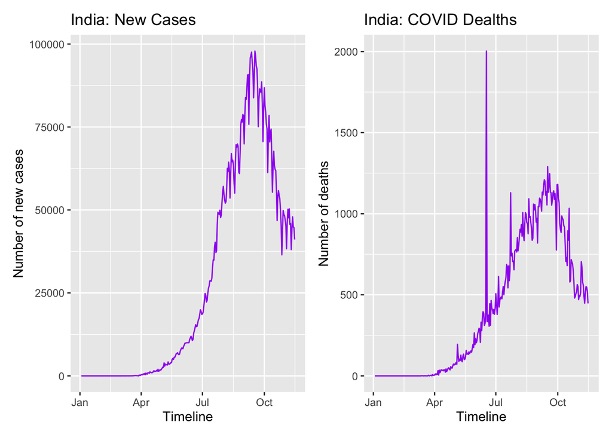

```r
india<-filter(covid_data, Country=="India")
I1<-ggplot (data = india, aes(x = Date_reported , y = New_cases)) +
    geom_line(colour='purple')+
  labs(title="India: New Cases",x = "Timeline", y = "Number of new cases")

I2<-ggplot (data = india, aes(x = Date_reported , y = New_deaths)) +
    geom_line(colour='purple')+
  labs(title="India: COVID Dealths",x = "Timeline", y = "Number of deaths")

I1+I2
```

[figure not shown]

```r
brazil<-filter(covid_data, Country=="Brazil")
B1<-ggplot (data = india, aes(x = Date_reported , y = New_cases)) +
    geom_line(colour='green')+
  labs(title="Brazil: New Cases",x = "Timeline", y = "Number of new cases")

B2<-ggplot (data = brazil, aes(x = Date_reported , y = New_deaths)) +
    geom_line(colour='green')+
  labs(title="Brazil: COVID Dealths",x = "Timeline", y = "Number of deaths")

B1+B2
```

For Higher GDP per capita

```r
cov.gdp2 <- filter (cov, TotalCases>3000000 & gdp_pc>40000)
cov.gdp2 <-select(cov.gdp2, Country,TotalCases,gdp_pc,gpi_score)


cov.gdp2
```

```
## # A tibble: 1 x 4
##   Country                  TotalCases gdp_pc gpi_score
##   <chr>                         <int>  <int>     <dbl>
## 1 United States of America   10641431  47200      2.06
```

The United States is only country with a highest GDP with the largest number of Cases of COVID

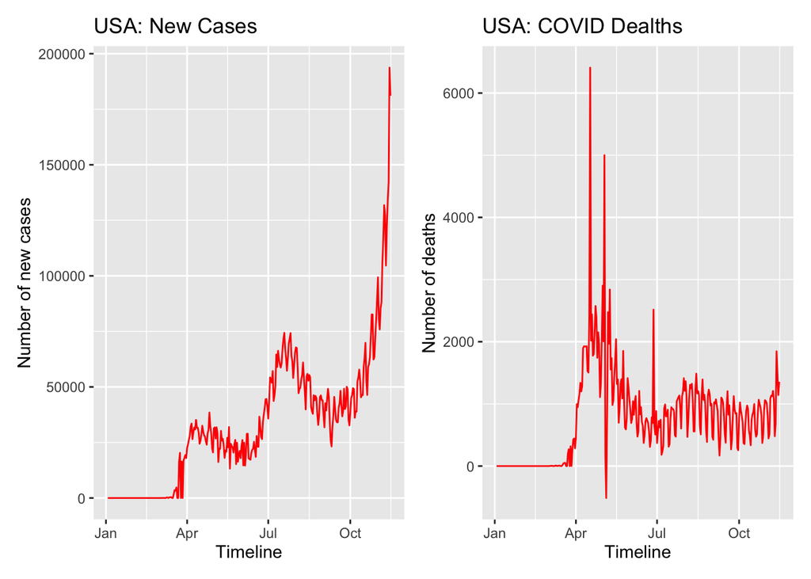

```r
usa<-filter(covid_data, Country=="United States of America")
usa1<-ggplot (data = usa, aes(x = Date_reported , y = New_cases)) +
    geom_line(colour='red')+
  labs(title="USA: New Cases",x = "Timeline", y = "Number of new cases")

usa2<-ggplot (data = usa, aes(x = Date_reported , y = New_deaths)) +
    geom_line(colour='red')+
  labs(title="USA: COVID Dealths",x = "Timeline", y = "Number of deaths")

usa1+usa2
```

In USA the cases peaked between July-August with a sharp rising number of cases in November, the number of dealths in USA had peaked between Apr-May, after which there was a sharp rise and fall in July. This can explain why we are in the middle of a second lockdown imposed in November

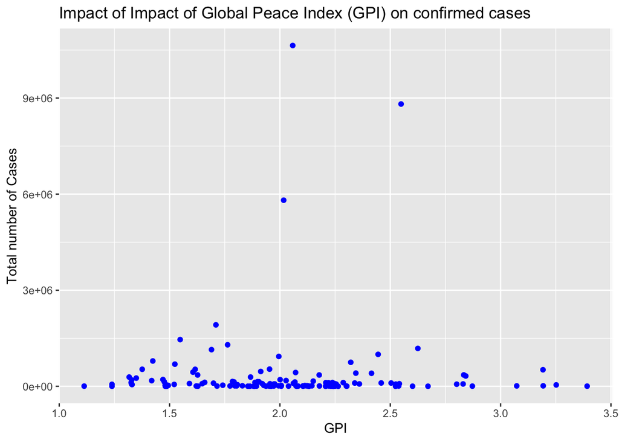

```r
#Visualising the impact of GPI on total number of COVID cases
ggplot (data = cov, aes(x = gpi_score , y = TotalCases)) +
    geom_point(colour='blue')+
  labs(title="Impact of Impact of Global Peace Index (GPI) on confirmed cases ",x = "GPI", y = "Total number of Cases")
```

```r
cov.gpi1 <- filter (cov, gpi_score>2.0 & TotalCases>5000000)
cov.gpi1 <-select(cov.gpi1, Country,TotalCases,gdp_pc,gpi_score)


cov.gpi1
```

```
## # A tibble: 3 x 4
##   Country                  TotalCases gdp_pc gpi_score
##   <chr>                         <int>  <int>     <dbl>
## 1 Brazil                      5810652  10800      2.02
## 2 India                       8814579   3500      2.55
## 3 United States of America   10641431  47200      2.06
```

Thus the countries with a higher global peace index with a sharp rise in the number cases are USA, Brazil and India. This means that the top 3 countries with the highest number of COVID cases are also countires delcared as "dangerously peaceful" with high amoount political unrest as per GPI rank.

# Conclusion

COVID fatalities are higher in countries with lower GDP per capita however while the total number of cases seem to be lesser in countries with the highest GDP per capita, the United States is a huge outlier to this data because it has the highest number of cases. Fatality is also higher in coutires deemed less peaceful, with a higher GPI index. The countries with the highest number of COVID cases: USA, Brazil and India are also countries with GPI score more than 2, which are considered "dangerously peaceful"